# Visualizing Chicago’s Changing Neighborhoods

Cory Rand

January 27, 2019

### Plot 1

This plot shows the major demographic changes that Chicago has experienced over the last several decades. The grey box shows the last 17 years, in which the white population has increased sharply, and minority populations have begun declining or leveled off. This time period is the area of focus for the rest of the graphs.

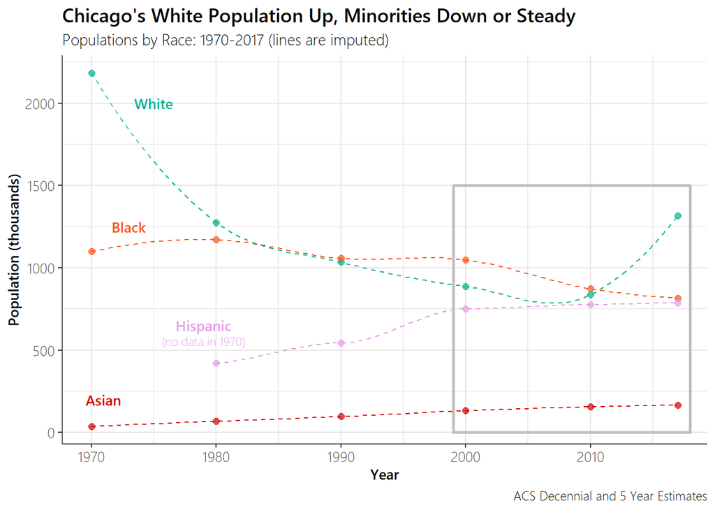

```r
demo_graph_data <- master %>%
  select(REGION, YEAR, nhwht, nhblk, asian, hisp) %>%
  distinct() %>%
  group_by(YEAR) %>%
  summarize(White = sum(nhwht, na.rm = T)/1000,
            Black = sum(nhblk, na.rm = T)/1000,
            Asian = sum(asian, na.rm = T)/1000,
            Hispanic = sum(hisp, na.rm = T)/1000) %>%
  filter(White != 0) %>%
  gather(key = "Race", value = "Pop", -c(YEAR))

demo_graph_data$Pop[demo_graph_data$Pop == 0] <- NA

  ggplot(demo_graph_data, aes(x = YEAR, y = Pop, col = Race)) +
  scale_color_manual(values= c("#D60000", "#FF5416","#E49DE8", "#00B28F")) +
  geom_point(size = 2, alpha = 0.7) +
  geom_smooth(linetype = "dashed", size = 0.5, alpha = 0.5) +
  labs(
  title="Chicago's White Population Up, Minorities Down or Steady",
  subtitle="Populations by Race: 1970-2017 (lines are imputed)",
  caption="ACS Decennial and 5 Year Estimates",
  x="Year",
  y="Population (thousands)"
  ) +
  geom_rect(xmin = 1999, xmax = 2018,
            ymin = 0, ymax = 1500,
            alpha = 0, color = "grey", size = 1) +
 # annotate("rect", xmin = 1999, xmax = Inf, ymin = 1500, ymax = Inf, fill= "grey", alpha = 0.2)  +
  annotate("text", label="White", x=1975, y=1998, size=3.5, color = "#00B28F", family="Segoe UI Semibold") +
  annotate("text", label="Black", x=1973, y=1250, size=3.5, color = "#FF5416", family="Segoe UI Semibold") +
  annotate("text", label="Asian", x=1971, y=198, size=3.5, color = "#D60000", family="Segoe UI Semibold") +
  annotate("text", label="Hispanic", x=1979, y=650, size=3.5, color = "#E49DE8", family="Segoe UI Semibold") +
  annotate("text", label="(no data in 1970)", x=1979, y=555, size=3, color = "#E49DE8", family = "Segoe UI Light") +
    theme_classic() +
  theme_custom +
      theme(legend.position="none")
```

### Plot 2

This next plot shows the demographic changes each neighborhood has experienced in the last 17 years. The lower right quadrant shows neighborhoods that have both increased their percentages of white residents and decreased their percentages of black residents. The graph also has an accompanying map showing the locations of those neighborhoods. That map also shows that the majority of neighborhoods in Chicago fit into this category.

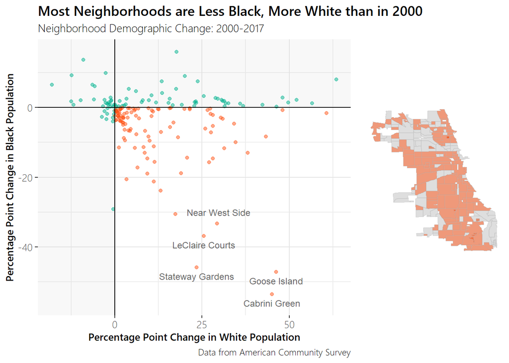

```r
plot_data <- neighborhood_master_wide %>%
    mutate(pblack_2000_2017 = (`2017_pblack` - `2000_pblack`)* 100,
           pwhite_2000_2017 = (`2017_pwhite` - `2000_pwhite`)* 100) %>%
  subset(subset = RegionID != "403159" & !is.na(pwhite_2000_2017), select=c(long, lat, group, RegionID, pwhite_2000_2017, pblack_2000_2017)) %>%
  left_join(zillow_shp@data[, c("RegionID", "Name")]) %>%
  distinct(RegionID, .keep_all = T) %>%
  mutate(highlight = pwhite_2000_2017 > 0 & pblack_2000_2017 < 0)

p1 <- plot_data %>%
ggplot(aes(x = pwhite_2000_2017, y = pblack_2000_2017, label = Name, col = highlight)) +
 annotate("rect", xmin = -Inf, xmax = 0, ymin = -Inf, ymax = Inf, fill= "grey", alpha = 0.1)  +
 annotate("rect", xmin = 0, xmax = Inf, ymin = 0, ymax = Inf, fill= "grey", alpha = 0.1)  +
  geom_jitter(alpha = 0.5) +
  geom_hline(yintercept = 0) +
  geom_vline(xintercept = 0) +
  geom_text(data = plot_data[which(plot_data$pwhite_2000_2017 > 20 & plot_data$pblack_2000_2017 < -35),],
            aes(x = pwhite_2000_2017, y = pblack_2000_2017, label = Name),
            size = 3.2,
            nudge_y = -2.5,
            family="Segoe UI Bold",
            color = "black",
            alpha = .6) +
  annotate("text", label="Near West Side", x=29.8, y=-30, alpha = .6, size=3.2, family="Segoe UI Bold") +
  scale_color_manual(values = c("#00B28F", "#FF5416")) +
       labs(x = "Percentage Point Change in White Population",
          y = "Percentage Point Change in Black Population",
          title = "Most Neighborhoods are Less Black, More White than in 2000",
          subtitle = "Neighborhood Demographic Change: 2000-2017",
          caption = "Data from American Community Survey") +
    theme_classic() +
  theme_custom +
   theme(axis.line = element_blank()) +
    theme(legend.position="none")

p2 <- neighborhood_master_wide %>%
    mutate(pblack_2000_2017 = `2017_pblack` - `2000_pblack`,
           pwhite_2000_2017 = `2017_pwhite` - `2000_pwhite`) %>%
  subset(subset = RegionID != "403159" & !is.na(pwhite_2000_2017), select=c(long, lat, group, RegionID, pwhite_2000_2017, pblack_2000_2017)) %>%
  left_join(zillow_shp@data[, c("RegionID", "Name")]) %>%
  mutate(highlight = pwhite_2000_2017 > 0 & pblack_2000_2017 < 0) %>%
ggplot(aes(x = long, y = lat)) +
    geom_polygon(aes(group = group), fill = "#FF5416", alpha = .5) +
    geom_path(aes(group = group),
              color = "grey", size = 0.01, alpha = 0.4) +
    gghighlight(highlight > 0,  unhighlighted_colour = alpha("grey", 0.2)) +
   #scale_fill_gradient2(low = "#D60000", high = "#00B28F") +
  coord_equal() +
    theme_minimal() +
    theme(axis.line = element_blank(),
    axis.text.x = element_blank(),
    axis.text.y = element_blank(),
    axis.ticks = element_blank(),
    axis.title.x = element_blank(),
    axis.title.y = element_blank(),
    panel.grid.major = element_blank(),
    panel.grid.minor = element_blank()) +
    theme(legend.position="none")

grid.newpage()
page.layout <- grid.layout(nrow = 1, ncol = 2, widths=c(.7, .3))
pushViewport(viewport(layout = page.layout))
print(p1, vp=viewport(layout.pos.row = 1, layout.pos.col = 1))
print(p2, vp=viewport(layout.pos.row = 1, layout.pos.col = 2))
```

### Plot 3

This next plot shows how the spatial distribution of the white population in Chicago has changed since 1970. From 1970-2000, many census tracts lost percentage shares of white residents. From 2000-2017, however, many of these same tracts experienced an influx of white residents.

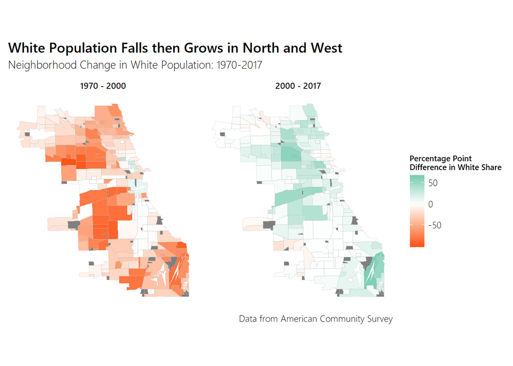

```r
neighborhood_master_wide %>%
    mutate(pwhite_1970_2000 = (`2000_pwhite` - `1970_pwhite`) * 100,
           pwhite_2000_2017 = (`2017_pwhite` - `2000_pwhite`)* 100) %>%
    subset(subset = RegionID != "403159", select=c(long, lat, group, RegionID, pwhite_1970_2000, pwhite_2000_2017)) %>%
  gather(key = "YEAR", value = "pwhite", -c(RegionID, long, lat, group)) %>%
  mutate(YEAR = gsub("pwhite_1970_2000", "1970 - 2000", YEAR),
         YEAR = gsub("pwhite_2000_2017", "2000 - 2017", YEAR)) %>%

    ggplot(aes(x = long, y = lat)) +
    geom_polygon(aes(fill = pwhite, group = RegionID)) +
    geom_path(aes(group = group),
                  color = "grey", size = 0.01, alpha = 0.4) +
    coord_equal() +
    facet_wrap(~YEAR) +
    scale_fill_gradient2(low = "#FF5416", high = "#00B28F") +
     labs(x = NULL,
          y = NULL,
          title = "White Population Falls then Grows in North and West",
          subtitle = "Neighborhood Change in White Population: 1970-2017",
          caption = "Data from American Community Survey",
          fill = "Percentage Point \nDifference in White Share") +
      theme_minimal() +
  theme_custom +
      theme(axis.line = element_blank(),
      axis.text.x = element_blank(),
      axis.text.y = element_blank(),
      axis.ticks = element_blank(),
      axis.title.x = element_blank(),
      axis.title.y = element_blank(),
      panel.grid.major = element_blank(),
      panel.grid.minor = element_blank(),
      legend.key.size = unit(0.5, "cm"),
      legend.title = element_text(size = 8),
      strip.text.x = element_text(family="Segoe UI Semibold"))
```

### Plot 4

This plot shows the correlations of Home Value, Race, and Population in Chicago’s neighborhoods at a single recent snapshot in time. Whiter neighborhoods have less population and more expensive homes.

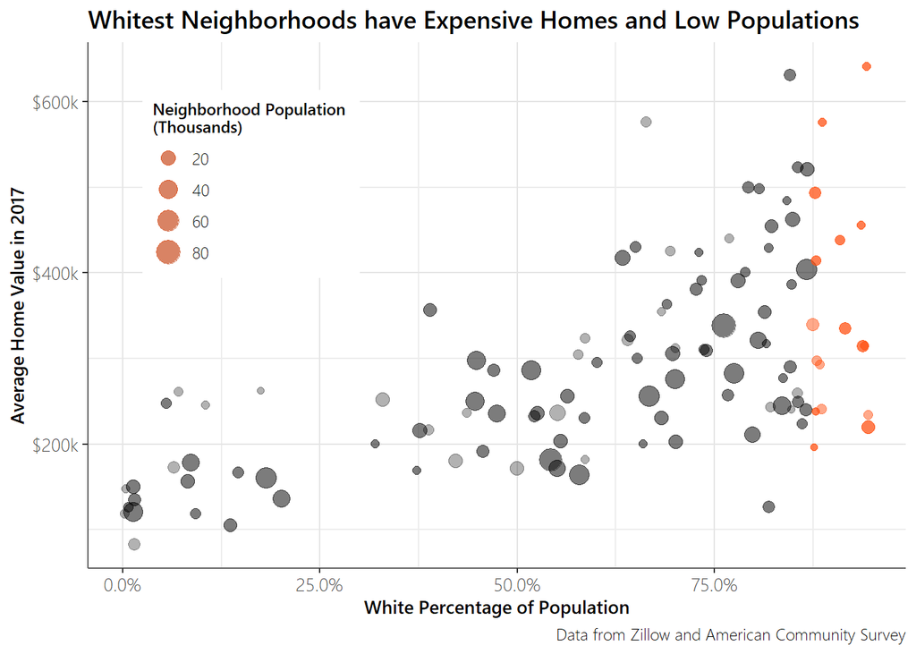

```r
plot_data <- master %>%
  filter(YEAR == 2017, pop > 0 & pop < 2000000) %>%
  mutate(pop_bins = cut(pop, breaks = seq(0, 99000, 33000), include.lowest = TRUE),
         pop = pop / 1000)

ggplot(plot_data[which(plot_data$pwhite < .87),], aes(x = pwhite, y = mean_hvi, size = pop)) +
  geom_point(alpha = .3) +
  geom_point(data = plot_data[which(plot_data$pwhite > .87),],
             aes(x = pwhite, y = mean_hvi, size = pop),
             col = "#FF5416",
             alpha = 0.5) +
  labs(
      title="Whitest Neighborhoods have Expensive Homes and Low Populations",
      #subtitle="Average Home Values and Demographic Data in 2017 ",
      caption="Data from Zillow and American Community Survey",
      x="White Percentage of Population",
      y="Average Home Value in 2017",
      size = "Neighborhood Population \n(Thousands)"
      ) +
  theme_classic() +
  #scale_color_manual(labels = c("0-33k", "33-66k", "66-99k"), values = c("#00B28F", "#FF5416","#D60000")) +
  scale_y_continuous(labels = c("0", "$200k", "$400k", "$600k")) +
  scale_x_continuous(labels = scales::percent) +
  theme(legend.position = c(.2, .73)) +
  theme_custom
```

### Plot 5

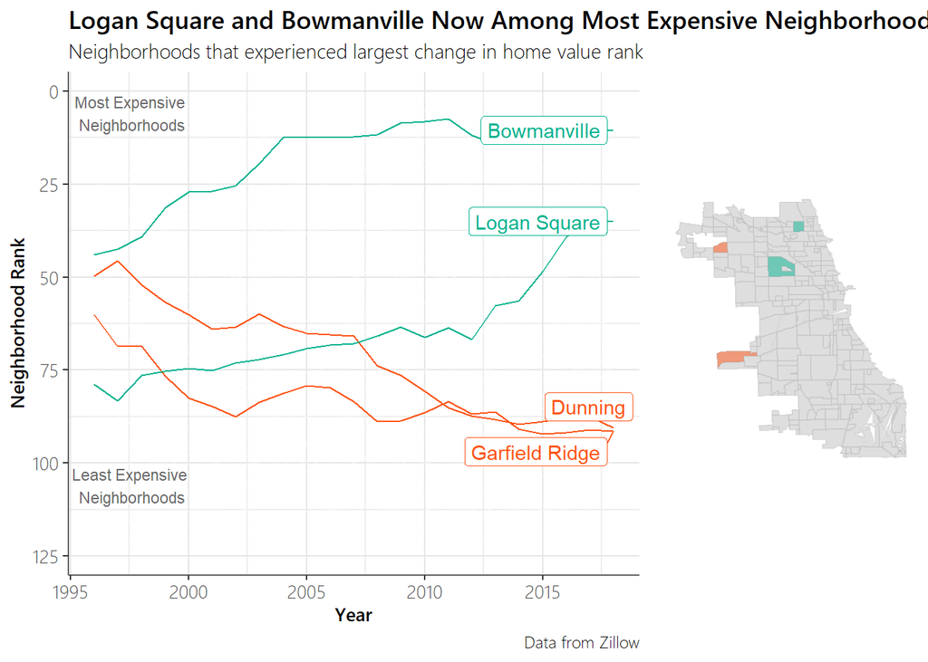

```r
master_wide_filt <- master_wide[which(!is.na(master_wide$change_rank)),]
up_neigh <- master_wide_filt$REGION[order(master_wide_filt$change_rank, decreasing = T)] %>% head(2)
down_neigh <- master_wide_filt$REGION[order(master_wide_filt$change_rank, decreasing = T)] %>% tail(2)
changing_neigh <- append(up_neigh, down_neigh)
losing_neigh <- master_wide_filt$REGION[which(master_wide_filt$change_rank < 0)]

rm(master_wide_filt)

p1 <- master %>%
  filter(YEAR > 1995, !is.na(RegionName)) %>%
  mutate(lost_rank = ifelse(REGION %in% losing_neigh, -1, 1)) %>%
ggplot(aes(x = YEAR, y = mean_rank, group = REGION)) +
  geom_line(aes(col = lost_rank)) +
  gghighlight(REGION %in% changing_neigh, label_key = RegionName, unhighlighted_colour = alpha("white", 0.2)) +
          labs(
          title="Logan Square and Bowmanville Now Among Most Expensive Neighborhoods",
          subtitle="Neighborhoods that experienced largest change in home value rank",
          caption="Data from Zillow",
          x="Year",
          y="Neighborhood Rank"
          ) +
          theme_classic() +
          scale_colour_gradient2(low = "#00B28F", high = "#FF5416") +
          scale_y_reverse() +
          theme_custom +
   annotate("text", label="Most Expensive \nNeighborhoods",
            x=1997.6, y=5.8, alpha = .6, family="Segoe UI Bold", size = 3) +
 annotate("text", label="Least Expensive \nNeighborhoods",
          x=1997.6, y=106, alpha = .6, family="Segoe UI Bold", size = 3)

plot_data <- neighborhood_master_wide %>%
              filter(RegionID != "403159") %>%
              mutate(highlight = RegionID %in% changing_neigh)
plot_data$highlight[which(plot_data$RegionID %in% down_neigh)] <- -1


p2 <-  ggplot(plot_data, aes(x = long, y = lat)) +
    geom_polygon(aes(fill = highlight, group = RegionID), alpha = .5) +
    geom_path(aes(group = group),
              color = "grey", size = 0.01, alpha = 0.4) +
    gghighlight(highlight != 0, label_key = RegionName,  unhighlighted_colour = alpha("grey", 0.2)) +
    scale_fill_gradient2(low = "#00B28F", high = "#FF5416") +
  coord_equal() +
    theme_minimal() +
    theme(axis.line = element_blank(),
    axis.text.x = element_blank(),
    axis.text.y = element_blank(),
    axis.ticks = element_blank(),
    axis.title.x = element_blank(),
    axis.title.y = element_blank(),
    panel.grid.major = element_blank(),
    panel.grid.minor = element_blank()) +
    theme(legend.position="none")


rm(plot_data)

grid.newpage()
page.layout <- grid.layout(nrow = 1, ncol = 2, widths=c(.7, .3))
pushViewport(viewport(layout = page.layout))
print(p1, vp=viewport(layout.pos.row = 1, layout.pos.col = 1))
print(p2, vp=viewport(layout.pos.row = 1, layout.pos.col = 2))
```

### Plot 6

This next plot is a directed scatter related to the plot above, showing changes in two variables - Cumulative Demolition and Construction Permits - of the 4 neighborhoods that have undergone the largest changes in home value rank. The cumulative numbers are scaled to the number of houses in each neighborhood in 2010. We see that the neighborhoods that experienced the most increase in value also have the most cumulative demolition and building permits.

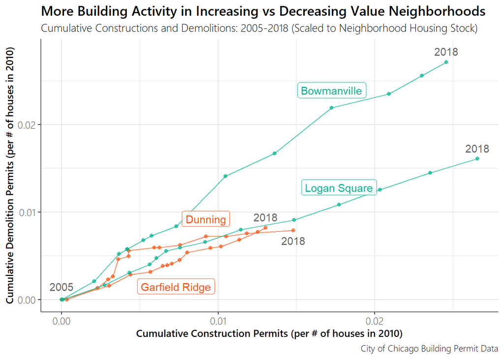

```r
plot_data <- master %>%
  subset(subset = REGION %in% changing_neigh, select = c(PERMIT_TYPE, REGION, YEAR, permits_cs, RegionName)) %>%
  distinct() %>%
  spread(key = "PERMIT_TYPE", value = "permits_cs") %>% filter(YEAR > 2004)
names(plot_data)[4:5] <- c("construction", "demolition")
#lag to replace NAs with values before it
plot_data %<>% group_by(REGION) %>%
              mutate(LAG_cons = dplyr::lag(construction,
                                           n = 1,
                                           order_by = YEAR),
                     LAG_des = dplyr::lag(demolition,
                                          n = 1,
                                          order_by = YEAR)) %>%
  left_join(master_wide[, c('REGION', '2010_hu')], by = "REGION")

plot_data$construction[which(is.na(plot_data$construction))] <- plot_data$LAG_cons[which(is.na(plot_data$construction))]
plot_data$construction[which(is.na(plot_data$construction))] <- 0
plot_data$demolition[which(is.na(plot_data$demolition))] <- plot_data$LAG_des[which(is.na(plot_data$demolition))]
plot_data$demolition[which(is.na(plot_data$demolition))] <- 0

plot_data1 <- plot_data %>% mutate(construction = construction / `2010_hu`,
                      demolition = demolition / `2010_hu`,
                      change_rank = REGION %in% losing_neigh) %>%
                      filter(!is.na(RegionName))

plot_data1[order(plot_data1$REGION, plot_data1$YEAR),] %>%
  ggplot(aes(x = construction, y = demolition, group = REGION, col = change_rank)) +
  geom_point(alpha = 0.7) +
  geom_path(alpha = 0.7) +
  labs(x = "Cumulative Construction Permits (per # of houses in 2010)",
         y = "Cumulative Demolition Permits (per # of houses in 2010)",
         title = "More Building Activity in Increasing vs Decreasing Value Neighborhoods",
         subtitle = "Cumulative Constructions and Demolitions: 2005-2018 (Scaled to Neighborhood Housing Stock)",
         caption = "City of Chicago Building Permit Data") +
  scale_color_manual(values = c("#FF5416","#00B28F")) +
  geom_label(data = plot_data1[which(plot_data1$YEAR == 2015 & plot_data1$RegionName != "Garfield Ridge"),],
             aes(x = construction,
                 y = demolition,
                 col = change_rank,
                 label = RegionName),
                 nudge_y = 0.002,
                 family = "Segoe UI Bold",
                 alpha = 0.7) +
  geom_text(data = plot_data1[which(plot_data1$YEAR == 2018 & plot_data1$RegionName != "Dunning"),],
            aes(x = construction,
                y = demolition,
                label = YEAR),
            col = "black",
            nudge_y = .0012,
            alpha = .6) +
  annotate("label", label="Garfield Ridge", x=.0073, y=.0015, alpha = .6, family="Segoe UI Bold", col = "#FF5416") +
  annotate("text", label="2018", x=.0148, y=.00674, alpha = .6, family="Segoe UI Bold") +
    annotate("text", label="2005", x=0, y=.0015, alpha = .6, family="Segoe UI Bold") +
  theme_classic() +
  theme(legend.position = "none") +
  theme_custom
```

### Plot 7

This next plot shows changes in housing supply for neighborhoods between 2000-2017. Neighborhoods with increasing supply are downtown and in the Northwest of Chicago, while neighborhods in the south and west are mostly losing housing stock.

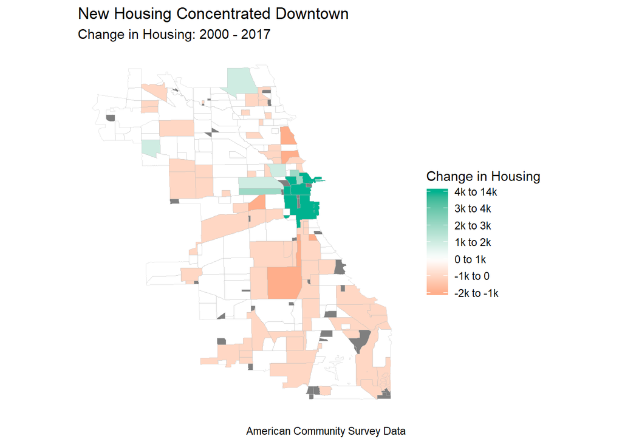

```r
plot_data <- neighborhood_master_wide %>%
   mutate(hu_2017_2000 = `2017_hu` - `2000_hu`,
          cuts = cut(hu_2017_2000,
                     breaks = c(-2000, -1000, 0, 1000, 2000, 3000, 4000, 14000),
                     ordered_result = T),
          levels = as.numeric(cuts) -3) %>%
    subset(subset = RegionID != "403159", select=c(long, lat, group, levels, RegionID, cuts))


ggplot(plot_data, aes(x = long, y = lat)) +
  geom_polygon(aes(fill = levels,
                   group = group)) +
       geom_path(aes(group = group),
                  color = "grey", size = 0.01, alpha = 0.4) +
    scale_fill_gradient2(low = "#FF5416", high = "#00B28F",
                         labels = c("-2k to -1k", "-1k to 0", "0 to 1k", "1k to 2k", "2k to 3k", "3k to 4k", "4k to 14k"),
                         name = "Change in Housing") +
  coord_equal() +
   labs(x = NULL,
        y = NULL,
        title = "New Housing Concentrated Downtown",
        subtitle = "Change in Housing: 2000 - 2017",
        caption = "American Community Survey Data") +
    theme_minimal() +
    theme(axis.line = element_blank(),
    axis.text.x = element_blank(),
    axis.text.y = element_blank(),
    axis.ticks = element_blank(),
    axis.title.x = element_blank(),
    axis.title.y = element_blank(),
    panel.grid.major = element_blank(),
    panel.grid.minor = element_blank())
```